# Loan Data from Prosper Exploration - Part 2

## by David Samy Yacoub

## Investigation Overview

> I'm most interested in figuring out what features are best for predicting the Loan Amount in the dataset. we'll see that Income Range will have the strongest effect on Loan Amount:The highest paid, get the higher loan. Also the ProsperScore, Occupation have a high effect. And if the borrower classified as a homowner can get a higher loan,

## Dataset Overview

> This data set contains 113,937 loans with 81 variables on each loan, including loan amount, borrower rate (or interest rate), current loan status, borrower income, and many others. I will focus on 15 variable

## let's start by looking at the distribution of the main variable of interest: LoanOriginalAmount

Loan amount shape is skewed-right with a peaks at 4000, 10000, 15000, 20000 and 25000 USD

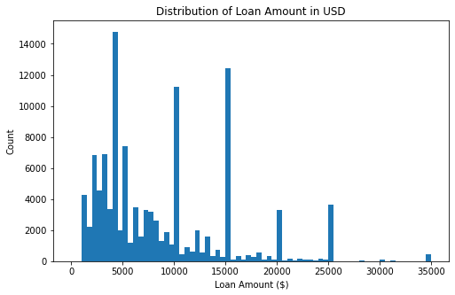

## Stated Monthly Income plot

Monthly Income has a long tailed distribution with a few borrowers with high income and the peak at 4666 USD monthly, Less than that, approval of the loan will be difficult and as the income increase The need for a loan is decrease

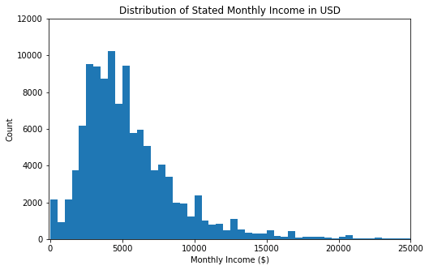

We see that the most borrow the loan to consolidation there debit then the most need to improve there homes then busines then to the car and go on.

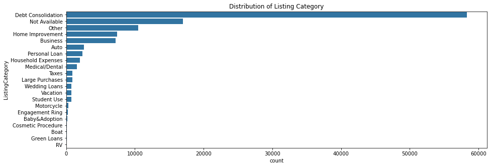

## Now let's do the same between loan Original Amount and the term

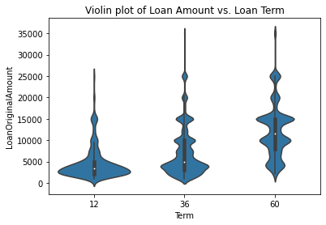